# Exercises

```python
import warnings
warnings.filterwarnings('ignore')

import pandas as pd
import numpy as np
import matplotlib.pyplot as plt
```

## Exercise 1

- Create a dataframe from the file `tilapia_pedigree.txt`. Name the dataframe `til_ped`. Show the first 10 and the last 10 number of rows.
- Obtain the number of records of the dataframe.
- Check the number of unique values for each column of the data frame.
- Change the name of the columns to `Id`, `Sire`, `Dam` and `Population`.
- For each Sire get the number of offspring.
- For each family (sire and dam) get the number of offspring.
- Assign an index that should contail the string `til_` followed by the number of the row. E.g. the index of the first recording should be `til_1` etc.
- Extract the 10th row of the dataframe.
- Create a new dataframe that contains the values of the original dataframe located between the 200th-300th rows and on the first three columns.
- Extract the rows where the last column contains values of either `Mindu` or `Kilola`.
- Extract the rows where the last column doesn't contail values of `Ruaha` and `Utete`.
- Create a copy of the original dataframe and name it `til_ped_new`. Delete the last column. Make sure this doesn't affect the original dataframe.

Create a dataframe from the file `tilapia_pedigree.txt`. Name the dataframe `til_ped`. Show the first 10 and the last 10 number of rows.

```python
til_ped = pd.read_csv('tilapia_pedigree.csv')
print(til_ped.head(10))
til_ped.tail(10)
```

```
     Animal   Father  Mother  Line
0  10977965  Sire_01  Dam_01  Wami
1  10978207  Sire_01  Dam_01  Wami
2  10978378  Sire_01  Dam_01  Wami
3  10978460  Sire_01  Dam_01  Wami
4  10977732  Sire_01  Dam_01  Wami
5  10978532  Sire_01  Dam_01  Wami
6  10978612  Sire_01  Dam_01  Wami
7  10977963  Sire_01  Dam_01  Wami
8  10977682  Sire_01  Dam_01  Wami
9  10978295  Sire_01  Dam_01  Wami
```

|  | Animal | Father | Mother | Line |
| --- | --- | --- | --- | --- |
| 1742 | 10978899 | Sire_035 | Dam_035 | Ruaha |
| 1743 | 10977635 | Sire_035 | Dam_035 | Ruaha |
| 1744 | 10978151 | Sire_035 | Dam_035 | Ruaha |
| 1745 | 10977918 | Sire_035 | Dam_035 | Ruaha |
| 1746 | 10977945 | Sire_035 | Dam_035 | Ruaha |
| 1747 | 10978369 | Sire_035 | Dam_035 | Ruaha |
| 1748 | 10978013 | Sire_035 | Dam_035 | Ruaha |
| 1749 | 10978579 | Sire_035 | Dam_035 | Ruaha |
| 1750 | 10977708 | Sire_035 | Dam_035 | Ruaha |
| 1751 | 10977975 | Sire_035 | Dam_035 | Ruaha |

```python
til_ped.info()
```

```
<class 'pandas.core.frame.DataFrame'>
RangeIndex: 1752 entries, 0 to 1751
Data columns (total 4 columns):
 #   Column  Non-Null Count  Dtype
---  ------  --------------  -----
 0   Animal  1752 non-null   int64
 1   Father  1752 non-null   object
 2   Mother  1752 non-null   object
 3   Line    1752 non-null   object
dtypes: int64(1), object(3)
memory usage: 54.9+ KB
```

Obtain the number of records of the dataframe.

```python
til_ped.shape
```

```
(1752, 4)
```

```python
til_ped.shape[1]
```

```
4
```

Check the number of unique values for each column of the data frame.

```python
til_ped.columns
```

```
Index(['Animal', 'Father', 'Mother', 'Line'], dtype='object')
```

```python
for column in til_ped.columns:
    print('The column ' + column + ' has ' + str(til_ped[column].nunique()) + ' unique records')
```

```
The column Animal has 1731 unique records
The column Father has 35 unique records
The column Mother has 36 unique records
The column Line has 9 unique records
```

Change the name of the columns to `Id`, `Sire`, `Dam` and `Population`.

```python
til_ped.columns = ['Id', 'Sire', 'Dam', 'Population']
```

```python
til_ped
```

|  | Id | Sire | Dam | Population |
| --- | --- | --- | --- | --- |
| 0 | 10977965 | Sire_01 | Dam_01 | Wami |
| 1 | 10978207 | Sire_01 | Dam_01 | Wami |
| 2 | 10978378 | Sire_01 | Dam_01 | Wami |
| 3 | 10978460 | Sire_01 | Dam_01 | Wami |
| 4 | 10977732 | Sire_01 | Dam_01 | Wami |
| ... | ... | ... | ... | ... |
| 1747 | 10978369 | Sire_035 | Dam_035 | Ruaha |
| 1748 | 10978013 | Sire_035 | Dam_035 | Ruaha |
| 1749 | 10978579 | Sire_035 | Dam_035 | Ruaha |
| 1750 | 10977708 | Sire_035 | Dam_035 | Ruaha |
| 1751 | 10977975 | Sire_035 | Dam_035 | Ruaha |

1752 rows × 4 columns

For each Sire get the number of offspring.

```python
til_ped['Sire'].value_counts()[til_ped['Sire'].unique()]
```

```
Sire
Sire_01     58
Sire_02     58
Sire_03     44
Sire_04     51
Sire_05     41
Sire_06     57
Sire_07     55
Sire_08     59
Sire_09     56
Sire_010    61
Sire_011    59
Sire_012    53
Sire_013    49
Sire_014    52
Sire_015    54
Sire_016    55
Sire_017    22
Sire_018    27
Sire_019    62
Sire_020    59
Sire_021    57
Sire_022    58
Sire_023    60
Sire_024    60
Sire_025    48
Sire_026    41
Sire_027    49
Sire_028    39
Sire_029    47
Sire_030    44
Sire_031    57
Sire_032    45
Sire_033    50
Sire_034    33
Sire_035    32
Name: count, dtype: int64
```

```python
for sire in til_ped['Sire'].unique():
    print(sire + ' has ' + str(til_ped[til_ped['Sire']==sire]['Id'].nunique()) + ' offspring')
```

```
Sire_01 has 58 offspring
Sire_02 has 58 offspring
Sire_03 has 44 offspring
Sire_04 has 51 offspring
Sire_05 has 41 offspring
Sire_06 has 57 offspring
Sire_07 has 55 offspring
Sire_08 has 59 offspring
Sire_09 has 56 offspring
Sire_010 has 61 offspring
Sire_011 has 59 offspring
Sire_012 has 53 offspring
Sire_013 has 49 offspring
Sire_014 has 52 offspring
Sire_015 has 54 offspring
Sire_016 has 55 offspring
Sire_017 has 22 offspring
Sire_018 has 27 offspring
Sire_019 has 62 offspring
Sire_020 has 58 offspring
Sire_021 has 57 offspring
Sire_022 has 58 offspring
Sire_023 has 60 offspring
Sire_024 has 60 offspring
Sire_025 has 48 offspring
Sire_026 has 41 offspring
Sire_027 has 49 offspring
Sire_028 has 39 offspring
Sire_029 has 47 offspring
Sire_030 has 44 offspring
Sire_031 has 57 offspring
Sire_032 has 45 offspring
Sire_033 has 50 offspring
Sire_034 has 33 offspring
Sire_035 has 32 offspring
```

For each family (sire and dam) get the number of offspring.

```python
til_ped['Family'] = til_ped['Sire'] + '_' + til_ped['Dam']
```

```python
family_labels = ["Family_0" + str(i) for i in range(1,37)]
```

```python
family_labels
```

```
['Family_01',
 'Family_02',
 'Family_03',
 'Family_04',
 'Family_05',
 'Family_06',
 'Family_07',
 'Family_08',
 'Family_09',
 'Family_010',
 'Family_011',
 'Family_012',
 'Family_013',
 'Family_014',
 'Family_015',
 'Family_016',
 'Family_017',
 'Family_018',
 'Family_019',
 'Family_020',
 'Family_021',
 'Family_022',
 'Family_023',
 'Family_024',
 'Family_025',
 'Family_026',
 'Family_027',
 'Family_028',
 'Family_029',
 'Family_030',
 'Family_031',
 'Family_032',
 'Family_033',
 'Family_034',
 'Family_035',
 'Family_036']
```

```python
original_labels = list(til_ped["Family"].unique())
```

```python
original_labels
```

```
['Sire_01_Dam_01',
 'Sire_02_Dam_02',
 'Sire_03_Dam_03',
 'Sire_04_Dam_04',
 'Sire_05_Dam_05',
 'Sire_06_Dam_06',
 'Sire_07_Dam_07',
 'Sire_08_Dam_08',
 'Sire_09_Dam_09',
 'Sire_010_Dam_010',
 'Sire_011_Dam_011',
 'Sire_012_Dam_012',
 'Sire_013_Dam_013',
 'Sire_014_Dam_014',
 'Sire_015_Dam_015',
 'Sire_016_Dam_016',
 'Sire_017_Dam_017',
 'Sire_018_Dam_018',
 'Sire_019_Dam_019',
 'Sire_020_Dam_020',
 'Sire_021_Dam_021',
 'Sire_022_Dam_022',
 'Sire_023_Dam_023',
 'Sire_024_Dam_024',
 'Sire_025_Dam_025',
 'Sire_026_Dam_026',
 'Sire_027_Dam_027',
 'Sire_028_Dam_028',
 'Sire_029_Dam_029',
 'Sire_030_Dam_030',
 'Sire_031_Dam_031',
 'Sire_032_Dam_032',
 'Sire_033_Dam_033',
 'Sire_034_Dam_034',
 'Sire_035_Dam_035',
 'Sire_013_Dam_036']
```

```python
family_labels = dict(zip(original_labels, family_labels))
```

```python
family_labels
```

```
{'Sire_01_Dam_01': 'Family_01',
 'Sire_02_Dam_02': 'Family_02',
 'Sire_03_Dam_03': 'Family_03',
 'Sire_04_Dam_04': 'Family_04',
 'Sire_05_Dam_05': 'Family_05',
 'Sire_06_Dam_06': 'Family_06',
 'Sire_07_Dam_07': 'Family_07',
 'Sire_08_Dam_08': 'Family_08',
 'Sire_09_Dam_09': 'Family_09',
 'Sire_010_Dam_010': 'Family_010',
 'Sire_011_Dam_011': 'Family_011',
 'Sire_012_Dam_012': 'Family_012',
 'Sire_013_Dam_013': 'Family_013',
 'Sire_014_Dam_014': 'Family_014',
 'Sire_015_Dam_015': 'Family_015',
 'Sire_016_Dam_016': 'Family_016',
 'Sire_017_Dam_017': 'Family_017',
 'Sire_018_Dam_018': 'Family_018',
 'Sire_019_Dam_019': 'Family_019',
 'Sire_020_Dam_020': 'Family_020',
 'Sire_021_Dam_021': 'Family_021',
 'Sire_022_Dam_022': 'Family_022',
 'Sire_023_Dam_023': 'Family_023',
 'Sire_024_Dam_024': 'Family_024',
 'Sire_025_Dam_025': 'Family_025',
 'Sire_026_Dam_026': 'Family_026',
 'Sire_027_Dam_027': 'Family_027',
 'Sire_028_Dam_028': 'Family_028',
 'Sire_029_Dam_029': 'Family_029',
 'Sire_030_Dam_030': 'Family_030',
 'Sire_031_Dam_031': 'Family_031',
 'Sire_032_Dam_032': 'Family_032',
 'Sire_033_Dam_033': 'Family_033',
 'Sire_034_Dam_034': 'Family_034',
 'Sire_035_Dam_035': 'Family_035',
 'Sire_013_Dam_036': 'Family_036'}
```

```python
til_ped["Family"] = til_ped["Family"].map(family_labels)
```

```python
til_ped
```

|  | Id | Sire | Dam | Population | Family |
| --- | --- | --- | --- | --- | --- |
| 0 | 10977965 | Sire_01 | Dam_01 | Wami | Family_01 |
| 1 | 10978207 | Sire_01 | Dam_01 | Wami | Family_01 |
| 2 | 10978378 | Sire_01 | Dam_01 | Wami | Family_01 |
| 3 | 10978460 | Sire_01 | Dam_01 | Wami | Family_01 |
| 4 | 10977732 | Sire_01 | Dam_01 | Wami | Family_01 |
| ... | ... | ... | ... | ... | ... |
| 1747 | 10978369 | Sire_035 | Dam_035 | Ruaha | Family_035 |
| 1748 | 10978013 | Sire_035 | Dam_035 | Ruaha | Family_035 |
| 1749 | 10978579 | Sire_035 | Dam_035 | Ruaha | Family_035 |
| 1750 | 10977708 | Sire_035 | Dam_035 | Ruaha | Family_035 |
| 1751 | 10977975 | Sire_035 | Dam_035 | Ruaha | Family_035 |

1752 rows × 5 columns

```python
til_ped['Family'].value_counts()[til_ped['Family'].unique()]
```

```
Family
Family_01     58
Family_02     58
Family_03     44
Family_04     51
Family_05     41
Family_06     57
Family_07     55
Family_08     59
Family_09     56
Family_010    61
Family_011    59
Family_012    53
Family_013    29
Family_014    52
Family_015    54
Family_016    55
Family_017    22
Family_018    27
Family_019    62
Family_020    59
Family_021    57
Family_022    58
Family_023    60
Family_024    60
Family_025    48
Family_026    41
Family_027    49
Family_028    39
Family_029    47
Family_030    44
Family_031    57
Family_032    45
Family_033    50
Family_034    33
Family_035    32
Family_036    20
Name: count, dtype: int64
```

```python
for family in til_ped['Family'].unique():
    print(family + ' has ' + str(til_ped[til_ped['Family']==family]['Id'].nunique()) + ' animals')
```

```
Family_01 has 58 animals
Family_02 has 58 animals
Family_03 has 44 animals
Family_04 has 51 animals
Family_05 has 41 animals
Family_06 has 57 animals
Family_07 has 55 animals
Family_08 has 59 animals
Family_09 has 56 animals
Family_010 has 61 animals
Family_011 has 59 animals
Family_012 has 53 animals
Family_013 has 29 animals
Family_014 has 52 animals
Family_015 has 54 animals
Family_016 has 55 animals
Family_017 has 22 animals
Family_018 has 27 animals
Family_019 has 62 animals
Family_020 has 58 animals
Family_021 has 57 animals
Family_022 has 58 animals
Family_023 has 60 animals
Family_024 has 60 animals
Family_025 has 48 animals
Family_026 has 41 animals
Family_027 has 49 animals
Family_028 has 39 animals
Family_029 has 47 animals
Family_030 has 44 animals
Family_031 has 57 animals
Family_032 has 45 animals
Family_033 has 50 animals
Family_034 has 33 animals
Family_035 has 32 animals
Family_036 has 20 animals
```

Assign an index that should contain the string `til_` followed by the number of the row. E.g. the index of the first recording should be `til_1` etc.

```python
til_ped.index = ['til_' + str(i) for i in til_ped.index]
til_ped
```

|  | Id | Sire | Dam | Population | Family |
| --- | --- | --- | --- | --- | --- |
| til_0 | 10977965 | Sire_01 | Dam_01 | Wami | Family_01 |
| til_1 | 10978207 | Sire_01 | Dam_01 | Wami | Family_01 |
| til_2 | 10978378 | Sire_01 | Dam_01 | Wami | Family_01 |
| til_3 | 10978460 | Sire_01 | Dam_01 | Wami | Family_01 |
| til_4 | 10977732 | Sire_01 | Dam_01 | Wami | Family_01 |
| ... | ... | ... | ... | ... | ... |
| til_1747 | 10978369 | Sire_035 | Dam_035 | Ruaha | Family_035 |
| til_1748 | 10978013 | Sire_035 | Dam_035 | Ruaha | Family_035 |
| til_1749 | 10978579 | Sire_035 | Dam_035 | Ruaha | Family_035 |
| til_1750 | 10977708 | Sire_035 | Dam_035 | Ruaha | Family_035 |
| til_1751 | 10977975 | Sire_035 | Dam_035 | Ruaha | Family_035 |

1752 rows × 5 columns

Extract the 10th row of the dataframe.

```python
til_ped.iloc[9]
```

```
Id             10978295
Sire            Sire_01
Dam              Dam_01
Population         Wami
Family        Family_01
Name: til_9, dtype: object
```

Create a new dataframe that contains the values of the original dataframe located between the 200th-300th rows and on the first three columns.

```python
til_ped_new = til_ped.iloc[199:301,:3]
til_ped_new
```

|  | Id | Sire | Dam |
| --- | --- | --- | --- |
| til_199 | 10975181 | Sire_08 | Dam_08 |
| til_200 | 10974989 | Sire_08 | Dam_08 |
| til_201 | 10975628 | Sire_08 | Dam_08 |
| til_202 | 10975325 | Sire_08 | Dam_08 |
| til_203 | 10975460 | Sire_08 | Dam_08 |
| ... | ... | ... | ... |
| til_296 | 10975071 | Sire_011 | Dam_011 |
| til_297 | 10975240 | Sire_011 | Dam_011 |
| til_298 | 10975550 | Sire_011 | Dam_011 |
| til_299 | 10974993 | Sire_011 | Dam_011 |
| til_300 | 10975229 | Sire_011 | Dam_011 |

102 rows × 3 columns

Extract the rows where the last column contains values of either `Mindu` or `Kilola`.

```python
til_ped_sub1 = til_ped[(til_ped['Population']=='Mindu')|(til_ped['Population']=='Kilola')]
til_ped_sub1
print(set(til_ped_sub1['Population']))
```

```
{'Mindu', 'Kilola'}
```

Extract the rows where the last column doesn't contail values of `Ruaha` and `Utete`.

```python
til_ped_sub2 = til_ped[(til_ped['Population'] != 'Ruaha') & (til_ped['Population'] != 'Utete')]
til_ped_sub2
print(set(til_ped_sub2['Population']))
```

```
{'Wami', 'Mindu', 'Kibasira', 'Kilola', 'Chemchem', 'Nyamisati', 'Bwawani'}
```

Create a copy of the original dataframe and name it `til_ped_new`. Delete the last column. Make sure this doesn't affect the original dataframe.

```python
til_ped
```

|  | Id | Sire | Dam | Population | Family |
| --- | --- | --- | --- | --- | --- |
| til_0 | 10977965 | Sire_01 | Dam_01 | Wami | Family_01 |
| til_1 | 10978207 | Sire_01 | Dam_01 | Wami | Family_01 |
| til_2 | 10978378 | Sire_01 | Dam_01 | Wami | Family_01 |
| til_3 | 10978460 | Sire_01 | Dam_01 | Wami | Family_01 |
| til_4 | 10977732 | Sire_01 | Dam_01 | Wami | Family_01 |
| ... | ... | ... | ... | ... | ... |
| til_1747 | 10978369 | Sire_035 | Dam_035 | Ruaha | Family_035 |
| til_1748 | 10978013 | Sire_035 | Dam_035 | Ruaha | Family_035 |
| til_1749 | 10978579 | Sire_035 | Dam_035 | Ruaha | Family_035 |
| til_1750 | 10977708 | Sire_035 | Dam_035 | Ruaha | Family_035 |
| til_1751 | 10977975 | Sire_035 | Dam_035 | Ruaha | Family_035 |

1752 rows × 5 columns

```python
til_ped_new = til_ped.copy()
del til_ped_new['Family']
til_ped_new
```

|  | Id | Sire | Dam | Population |
| --- | --- | --- | --- | --- |
| til_0 | 10977965 | Sire_01 | Dam_01 | Wami |
| til_1 | 10978207 | Sire_01 | Dam_01 | Wami |
| til_2 | 10978378 | Sire_01 | Dam_01 | Wami |
| til_3 | 10978460 | Sire_01 | Dam_01 | Wami |
| til_4 | 10977732 | Sire_01 | Dam_01 | Wami |
| ... | ... | ... | ... | ... |
| til_1747 | 10978369 | Sire_035 | Dam_035 | Ruaha |
| til_1748 | 10978013 | Sire_035 | Dam_035 | Ruaha |
| til_1749 | 10978579 | Sire_035 | Dam_035 | Ruaha |
| til_1750 | 10977708 | Sire_035 | Dam_035 | Ruaha |
| til_1751 | 10977975 | Sire_035 | Dam_035 | Ruaha |

1752 rows × 4 columns

## Exercise 2

- Create a dataframe from the file `tilapia_pheno.txt`. Name the dataframe til_pheno. Show the first 10 and the last 10 number of rows. The columns are separated using `;`.
- How many records are in the dataframe.
- For the non-numeric columns estimate the number of unique records.
- Show a descriptive statistics summary.
- Which `Location` has the animals with the highest mean final weight.
- Which `Line` has the lowest mean final weight.
- Estimate correlations between the weight and length related columns.
- Create a new dataframe keeping only records where the difference between `Weight_final` and `Weight_initial` is above 100.
- Create a new dataframe keeping only records where the difference between `Weight_final` and `Weight_initial` is above 120 and the difference between `Length_final` and `Length_initial` is above 5.
- Create histograms depicting the `Weight_final` for each of the `Location.
- Create a boxplot depicting the difference between `Weight_final` and `Weight_initial` for each `Line`.

Create a dataframe from the file `tilapia_pheno.txt` . Name the dataframe til_pheno. Show the first 10 and the last 10 number of rows. The columns are separated using ;

```python
pd.read_csv?
```

[output not shown]

[output cut: 385 more lines]

[output not shown]

```python
til_pheno = pd.read_csv('tilapia_pheno.txt', sep=';')
til_pheno
```

|  | Animal_Id | Location | Line | Weight_initial | Weight_final | Length_initial | Length_final |
| --- | --- | --- | --- | --- | --- | --- | --- |
| 0 | 10977965 | Kunduchi | Wami | 84.30 | 201.50 | 14.2 | 18.0 |
| 1 | 10978207 | Kunduchi | Wami | 67.80 | 0.00 | 13.4 | 0.0 |
| 2 | 10978378 | Kunduchi | Wami | 103.94 | 225.90 | 14.4 | 18.5 |
| 3 | 10978460 | Kunduchi | Wami | 84.85 | 239.20 | 14.5 | 19.9 |
| 4 | 10977732 | Kunduchi | Wami | 78.29 | 195.60 | 14.0 | 19.0 |
| ... | ... | ... | ... | ... | ... | ... | ... |
| 1747 | 10978369 | Pangani | Ruaha | 26.93 | 86.12 | 9.4 | 13.8 |
| 1748 | 10978013 | Pangani | Ruaha | 18.02 | 0.00 | 8.6 | 0.0 |
| 1749 | 10978579 | Pangani | Ruaha | 46.97 | 101.54 | 11.0 | 14.0 |
| 1750 | 10977708 | Pangani | Ruaha | 39.83 | 64.24 | 10.7 | 13.4 |
| 1751 | 10977975 | Pangani | Ruaha | 32.14 | 57.24 | 10.0 | 12.0 |

1752 rows × 7 columns

```python
til_pheno.head(10)
```

|  | Animal_Id | Location | Line | Weight_initial | Weight_final | Length_initial | Length_final |
| --- | --- | --- | --- | --- | --- | --- | --- |
| 0 | 10977965 | Kunduchi | Wami | 84.30 | 201.5 | 14.2 | 18.0 |
| 1 | 10978207 | Kunduchi | Wami | 67.80 | 0.0 | 13.4 | 0.0 |
| 2 | 10978378 | Kunduchi | Wami | 103.94 | 225.9 | 14.4 | 18.5 |
| 3 | 10978460 | Kunduchi | Wami | 84.85 | 239.2 | 14.5 | 19.9 |
| 4 | 10977732 | Kunduchi | Wami | 78.29 | 195.6 | 14.0 | 19.0 |
| 5 | 10978532 | Kunduchi | Wami | 89.93 | 220.0 | 14.7 | 19.0 |
| 6 | 10978612 | Kunduchi | Wami | 117.83 | 270.9 | 15.0 | 20.0 |
| 7 | 10977963 | Kunduchi | Wami | 92.48 | 209.4 | 14.9 | 18.3 |
| 8 | 10977682 | Kunduchi | Wami | 95.54 | 178.8 | 14.9 | 17.7 |
| 9 | 10978295 | Kunduchi | Wami | 70.27 | 135.2 | 13.3 | 16.0 |

```python
til_pheno.tail(10)
```

|  | Animal_Id | Location | Line | Weight_initial | Weight_final | Length_initial | Length_final |
| --- | --- | --- | --- | --- | --- | --- | --- |
| 1742 | 10978899 | Pangani | Ruaha | 39.64 | 0.00 | 10.8 | 0.0 |
| 1743 | 10977635 | Pangani | Ruaha | 30.60 | 80.03 | 9.8 | 13.1 |
| 1744 | 10978151 | Pangani | Ruaha | 29.85 | 40.00 | 9.7 | 10.7 |
| 1745 | 10977918 | Pangani | Ruaha | 40.80 | 103.74 | 10.8 | 14.0 |
| 1746 | 10977945 | Pangani | Ruaha | 49.54 | 124.83 | 11.4 | 14.7 |
| 1747 | 10978369 | Pangani | Ruaha | 26.93 | 86.12 | 9.4 | 13.8 |
| 1748 | 10978013 | Pangani | Ruaha | 18.02 | 0.00 | 8.6 | 0.0 |
| 1749 | 10978579 | Pangani | Ruaha | 46.97 | 101.54 | 11.0 | 14.0 |
| 1750 | 10977708 | Pangani | Ruaha | 39.83 | 64.24 | 10.7 | 13.4 |
| 1751 | 10977975 | Pangani | Ruaha | 32.14 | 57.24 | 10.0 | 12.0 |

How many records are in the dataframe.

```python
til_pheno.shape
```

```
(1752, 7)
```

```python
til_pheno.size
```

```
12264
```

For the non-numeric columns estimate the number of unique records.

```python
non_numeric = ['Animal_Id', 'Location', 'Line']
for column in non_numeric:
    print(column + ' has ' + str(til_pheno[column].nunique()) + ' values')
```

```
Animal_Id has 1731 values
Location has 2 values
Line has 9 values
```

Show a descriptive statistics summary.

```python
til_pheno.describe()
```

|  | Animal_Id | Weight_initial | Weight_final | Length_initial | Length_final |
| --- | --- | --- | --- | --- | --- |
| count | 1.752000e+03 | 1752.000000 | 1752.000000 | 1752.000000 | 1752.000000 |
| mean | 1.097639e+07 | 46.031792 | 90.575148 | 11.047203 | 11.603253 |
| std | 1.263501e+03 | 22.049627 | 66.613054 | 1.857820 | 6.292099 |
| min | 1.097305e+07 | 8.440000 | 0.000000 | 5.000000 | 0.000000 |
| 25% | 1.097534e+07 | 29.145000 | 42.500000 | 9.700000 | 10.800000 |
| 50% | 1.097614e+07 | 41.800000 | 85.600000 | 11.000000 | 13.500000 |
| 75% | 1.097762e+07 | 60.137500 | 138.200000 | 12.400000 | 16.000000 |
| max | 1.098860e+07 | 128.850000 | 325.400000 | 16.700000 | 21.500000 |

Which `Location` has the animals with the highest mean final weight.

```python
set(til_pheno['Location'])
```

```
{'Kunduchi', 'Pangani'}
```

```python
sum(til_pheno[til_pheno['Location']=='Kunduchi']['Weight_final'])/len(til_pheno[til_pheno['Location']=='Kunduchi']['Weight_final'])
```

```
85.10319999999996
```

```python
til_pheno[til_pheno['Location']=='Kunduchi']['Weight_final'].mean()
```

```
85.1032
```

```python
til_pheno[til_pheno['Location']=='Pangani']['Weight_final'].mean()
```

```
96.03461801596352
```

Which `Line` has the lowest mean final weight.

```python
lines = set(til_pheno['Line'])
lines
```

```
{'Bwawani',
 'Chemchem',
 'Kibasira',
 'Kilola',
 'Mindu',
 'Nyamisati',
 'Ruaha',
 'Utete',
 'Wami'}
```

```python
for line in lines:
    mean_line = til_pheno[til_pheno['Line']==line]['Weight_final'].mean()
    print(line + ' has a mean final weight of ' + str(mean_line))
```

```
Wami has a mean final weight of 139.6120379146919
Mindu has a mean final weight of 89.12855895196508
Ruaha has a mean final weight of 44.26643750000001
Kibasira has a mean final weight of 72.71000000000001
Utete has a mean final weight of 86.00023809523809
Chemchem has a mean final weight of 98.26014150943395
Kilola has a mean final weight of 90.67379679144385
Nyamisati has a mean final weight of 91.50961538461539
Bwawani has a mean final weight of 82.85449494949496
```

Estimate correlations between the weight and length related columns.

```python
til_pheno[['Weight_initial','Weight_final','Length_initial','Length_final']].corr()
```

|  | Weight_initial | Weight_final | Length_initial | Length_final |
| --- | --- | --- | --- | --- |
| Weight_initial | 1.000000 | 0.514052 | 0.957177 | 0.312355 |
| Weight_final | 0.514052 | 1.000000 | 0.523587 | 0.886276 |
| Length_initial | 0.957177 | 0.523587 | 1.000000 | 0.329928 |
| Length_final | 0.312355 | 0.886276 | 0.329928 | 1.000000 |

Create a new dataframe keeping only records where the difference between `Weight_final` and `Weight_initial` is above 100.

```python
til_pheno_red1 = til_pheno[(til_pheno['Weight_final'] - til_pheno['Weight_initial']) > 100]
til_pheno_red1
```

|  | Animal_Id | Location | Line | Weight_initial | Weight_final | Length_initial | Length_final |
| --- | --- | --- | --- | --- | --- | --- | --- |
| 0 | 10977965 | Kunduchi | Wami | 84.30 | 201.50 | 14.2 | 18.0 |
| 2 | 10978378 | Kunduchi | Wami | 103.94 | 225.90 | 14.4 | 18.5 |
| 3 | 10978460 | Kunduchi | Wami | 84.85 | 239.20 | 14.5 | 19.9 |
| 4 | 10977732 | Kunduchi | Wami | 78.29 | 195.60 | 14.0 | 19.0 |
| 5 | 10978532 | Kunduchi | Wami | 89.93 | 220.00 | 14.7 | 19.0 |
| ... | ... | ... | ... | ... | ... | ... | ... |
| 1647 | 10978598 | Pangani | Kilola | 29.52 | 156.09 | 9.7 | 17.5 |
| 1655 | 10978010 | Pangani | Kilola | 28.18 | 169.27 | 9.6 | 16.5 |
| 1674 | 10978476 | Pangani | Ruaha | 33.07 | 168.23 | 10.3 | 17.7 |
| 1681 | 10977885 | Pangani | Ruaha | 67.57 | 181.20 | 12.6 | 17.0 |
| 1728 | 10978056 | Pangani | Ruaha | 19.51 | 134.50 | 8.7 | 15.2 |

280 rows × 7 columns

Create a new dataframe keeping only records where the difference between `Weight_final` and `Weight_initial` is above 120 and the difference between `Length_final` and `Length_initial` is above 5.

```python
til_pheno_red2 = til_pheno[(til_pheno['Weight_final'] - til_pheno['Weight_initial'] > 120)
                           & (til_pheno['Length_final'] - til_pheno['Length_initial'] > 5)]
til_pheno_red2
```

|  | Animal_Id | Location | Line | Weight_initial | Weight_final | Length_initial | Length_final |
| --- | --- | --- | --- | --- | --- | --- | --- |
| 3 | 10978460 | Kunduchi | Wami | 84.85 | 239.20 | 14.5 | 19.9 |
| 17 | 10978130 | Kunduchi | Wami | 69.83 | 204.70 | 13.3 | 19.0 |
| 25 | 10977686 | Kunduchi | Wami | 59.62 | 205.20 | 12.6 | 18.0 |
| 36 | 10978226 | Kunduchi | Wami | 78.25 | 261.10 | 13.4 | 19.5 |
| 37 | 10977804 | Kunduchi | Wami | 80.97 | 241.20 | 13.3 | 18.7 |
| ... | ... | ... | ... | ... | ... | ... | ... |
| 1561 | 10977745 | Pangani | Bwawani | 82.45 | 231.06 | 13.2 | 18.5 |
| 1645 | 10978364 | Pangani | Kilola | 57.96 | 178.81 | 12.8 | 18.0 |
| 1647 | 10978598 | Pangani | Kilola | 29.52 | 156.09 | 9.7 | 17.5 |
| 1655 | 10978010 | Pangani | Kilola | 28.18 | 169.27 | 9.6 | 16.5 |
| 1674 | 10978476 | Pangani | Ruaha | 33.07 | 168.23 | 10.3 | 17.7 |

128 rows × 7 columns

Create histograms depicting the `Weight_final` for each of the `Location.

```python
set(til_pheno['Location'])
```

```
{'Kunduchi', 'Pangani'}
```

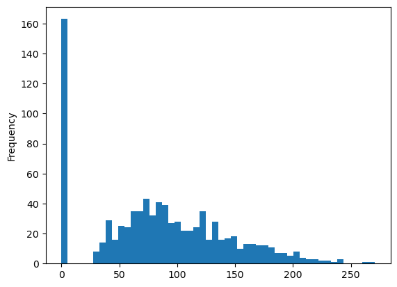

```python
til_pheno[til_pheno['Location']=='Kunduchi']['Weight_final'].plot(kind='hist',bins=50)
```

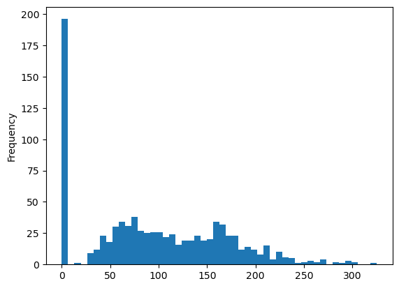

```python
til_pheno[til_pheno['Location']=='Pangani']['Weight_final'].plot(kind='hist',bins=50)
```

Create a boxplot depicting the difference between `Weight_final` and `Weight_initial` for each `Line`.

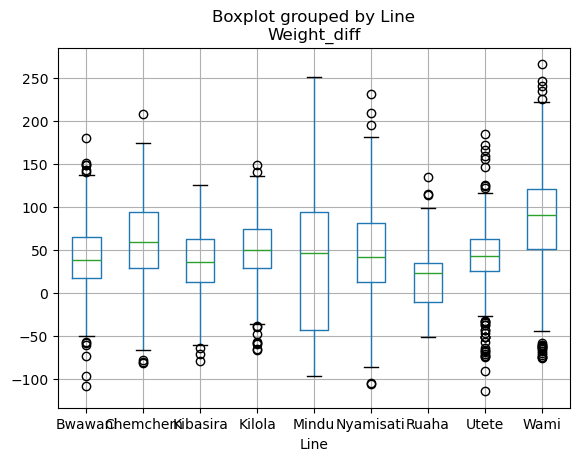

```python
til_pheno['Weight_diff'] = til_pheno['Weight_final'] - til_pheno['Weight_initial']
til_pheno.boxplot(column='Weight_diff', by='Line')
```